# Econométrie_var_quali

Moussa

2024-09-02

# Charger les données

```r
library(readr)

Essence <- read.csv("C:/Users/sisso/OneDrive/Documents/GitHub/SORADATA/ACP-R/ACP_University/Econométrie_var_qualitatives/Econométrie des var_qualitatives/Dataset/R2.csv",
                    sep = ";", stringsAsFactors = TRUE)
```

# Statistiques descriptives

```r
summary(Essence)
```

```
##       YEAR            G               PG              Y              PNC
##  Min.   :1960   Min.   :129.7   Min.   :0.914   Min.   : 3923   Min.   :0.991
##  1st Qu.:1969   1st Qu.:192.7   1st Qu.:1.039   1st Qu.: 6139   1st Qu.:1.045
##  Median :1978   Median :235.2   Median :1.923   Median : 8028   Median :1.484
##  Mean   :1978   Mean   :226.1   Mean   :2.317   Mean   : 7928   Mean   :1.671
##  3rd Qu.:1986   3rd Qu.:270.0   3rd Qu.:3.718   3rd Qu.: 9591   3rd Qu.:2.260
##  Max.   :1995   Max.   :297.8   Max.   :4.109   Max.   :11934   Max.   :2.815
##       PUC             POP        Glorious. Gender   TM.France
##  Min.   :0.836   Min.   :180.7   N:44      F:36   Min.   :160.0
##  1st Qu.:1.030   1st Qu.:202.2   Y:28      M:36   1st Qu.:160.0
##  Median :1.847   Median :221.4                    Median :166.0
##  Mean   :2.344   Mean   :221.9                    Mean   :166.1
##  3rd Qu.:3.781   3rd Qu.:241.2                    3rd Qu.:171.0
##  Max.   :5.224   Max.   :263.2                    Max.   :175.0
```

```r
str(Essence)
```

```
## 'data.frame':    72 obs. of  10 variables:
##  $ YEAR     : int  1960 1961 1962 1963 1964 1965 1966 1967 1968 1969 ...
##  $ G        : num  130 131 137 142 149 ...
##  $ PG       : num  0.925 0.914 0.919 0.918 0.914 ...
##  $ Y        : num  6036 6113 6271 6378 6727 ...
##  $ PNC      : num  1.04 1.04 1.04 1.03 1.03 ...
##  $ PUC      : num  0.836 0.869 0.948 0.96 1.001 ...
##  $ POP      : num  181 184 186 189 192 ...
##  $ Glorious.: Factor w/ 2 levels "N","Y": 2 2 2 2 2 2 2 2 2 2 ...
##  $ Gender   : Factor w/ 2 levels "F","M": 2 2 2 2 2 2 2 2 2 2 ...
##  $ TM.France: int  169 170 170 170 170 170 170 170 170 170 ...
```

# Créer la variable de consommation d’essence par tête

```r
Essence$GPOP <- Essence$G / Essence$POP

# Créer les variables en logarithme
Essence$LOGGPOP <- log(Essence$GPOP)
Essence$LOGPG <- log(Essence$PG)
Essence$LOGY <- log(Essence$Y)
Essence$LOGPNC <- log(Essence$PNC)
Essence$LOGPPUC <- log(Essence$PUC)

# Afficher les premières lignes du dataframe mis à jour
head(Essence)
```

```
##   YEAR     G    PG    Y   PNC   PUC   POP Glorious. Gender TM.France      GPOP
## 1 1960 129.7 0.925 6036 1.045 0.836 180.7         Y      M       169 0.7177643
## 2 1961 131.3 0.914 6113 1.045 0.869 183.7         Y      M       170 0.7147523
## 3 1962 137.1 0.919 6271 1.041 0.948 186.5         Y      M       170 0.7351206
## 4 1963 141.6 0.918 6378 1.035 0.960 189.2         Y      M       170 0.7484144
## 5 1964 148.8 0.914 6727 1.032 1.001 191.9         Y      M       170 0.7754039
## 6 1965 155.9 0.949 7027 1.009 0.994 194.3         Y      M       170 0.8023675
##      LOGGPOP       LOGPG     LOGY      LOGPNC       LOGPPUC
## 1 -0.3316141 -0.07796154 8.705497 0.044016885 -0.1791266659
## 2 -0.3358192 -0.08992471 8.718173 0.044016885 -0.1404121537
## 3 -0.3077207 -0.08446916 8.743691 0.040181790 -0.0534007767
## 4 -0.2897985 -0.08555789 8.760610 0.034401427 -0.0408219945
## 5 -0.2543713 -0.08992471 8.813885 0.031498667  0.0009995003
## 6 -0.2201886 -0.05234648 8.857515 0.008959741 -0.0060180723
```

# 5. Quelle est la moyenne de l’indice des prix des nouvelles voitures? La médiane de l’indice des prix des voitures d’occasion? La variance de la consommation par tête.

```r
moyenne_pnc <- mean(Essence$PNC, na.rm = TRUE)
print(paste("Moyenne de l'indice des prix des nouvelles voitures :", round(moyenne_pnc,2)))
```

```
## [1] "Moyenne de l'indice des prix des nouvelles voitures : 1.67"
```

```r
# Médiane de l'indice des prix des voitures d'occasion (PUC)
mediane_puc <- median(Essence$PUC, na.rm = TRUE)
print(paste("Médiane de l'indice des prix des voitures d'occasion:", round(mediane_puc, 2)))
```

```
## [1] "Médiane de l'indice des prix des voitures d'occasion: 1.85"
```

```r
# Variance de la consommation par tête (GPOP)
variance_gpop <- var(Essence$GPOP, na.rm = TRUE)
print(paste("Variance de la consommation par tête:", round(variance_gpop, 2)))
```

```
## [1] "Variance de la consommation par tête: 0.02"
```

```r
# Statistiques descriptives supplémentaires
summary(Essence[, c("PNC", "PUC", "GPOP")])
```

```
##       PNC             PUC             GPOP
##  Min.   :0.991   Min.   :0.836   Min.   :0.7148
##  1st Qu.:1.045   1st Qu.:1.030   1st Qu.:0.9529
##  Median :1.484   Median :1.847   Median :1.0533
##  Mean   :1.671   Mean   :2.344   Mean   :1.0069
##  3rd Qu.:2.260   3rd Qu.:3.781   3rd Qu.:1.1147
##  Max.   :2.815   Max.   :5.224   Max.   :1.1739
```

# 6. Effectuez une régression simple dont les résultats seront stockés dans regtotal, avec pour endogène LOGGPOP et pour exogène LOGY. Interprétez les résultats. Créez l’objet droitegpopy qui correspond aux valeurs prédites 𝐿𝑂𝐺𝐺𝑃𝑂𝑃 ̂ de la régression. (En reprenant manuellement les coefficients de la régression). Affichez la droite de régression sur le nuage de points.

```r
regtotal=lm(LOGGPOP~LOGY, data = Essence)
summary(regtotal)
```

```
##
## Call:
## lm(formula = LOGGPOP ~ LOGY, data = Essence)
##
## Residuals:
##      Min       1Q   Median       3Q      Max
## -0.25531 -0.06869  0.01078  0.05886  0.20263
##
## Coefficients:
##             Estimate Std. Error t value Pr(>|t|)
## (Intercept) -3.14387    0.38856  -8.091 1.24e-11 ***
## LOGY         0.35138    0.04346   8.086 1.27e-11 ***
## ---
## Signif. codes:  0 '***' 0.001 '**' 0.01 '*' 0.05 '.' 0.1 ' ' 1
##
## Residual standard error: 0.1091 on 70 degrees of freedom
## Multiple R-squared:  0.4829, Adjusted R-squared:  0.4756
## F-statistic: 65.38 on 1 and 70 DF,  p-value: 1.269e-11
```

```r
sum(regtotal$residuals)
```

```
## [1] -3.122502e-16
```

```r
deviance(regtotal)
```

```
## [1] 0.8328285
```

# Une regression linéaire uniquement pour les hommes

```r
regtotal_Masculin=lm(LOGGPOP~LOGY, Gender=="M", data = Essence)
summary(regtotal_Masculin)
```

```
##
## Call:
## lm(formula = LOGGPOP ~ LOGY, data = Essence, subset = Gender ==
##     "M")
##
## Residuals:
##      Min       1Q   Median       3Q      Max
## -0.07148 -0.05572 -0.02758  0.06313  0.12030
##
## Coefficients:
##             Estimate Std. Error t value Pr(>|t|)
## (Intercept) -6.04963    0.51415  -11.77 1.55e-13 ***
## LOGY         0.66359    0.05642   11.76 1.56e-13 ***
## ---
## Signif. codes:  0 '***' 0.001 '**' 0.01 '*' 0.05 '.' 0.1 ' ' 1
##
## Residual standard error: 0.06836 on 34 degrees of freedom
## Multiple R-squared:  0.8027, Adjusted R-squared:  0.7969
## F-statistic: 138.3 on 1 and 34 DF,  p-value: 1.564e-13
```

# On constate que le LOGY est significatif au seuil de 5 % voire 10 % : alors de ce fait on réjette l’hypothèse nullité de var explicatives.

# Créer l’objet droitegpopy avec les valeurs prédites

```r
coefficients <- coef(regtotal)
Essence$droitegpopy <- coefficients[1] + coefficients[2] * Essence$LOGY
```

# Créer le nuage de points avec la droite de régression

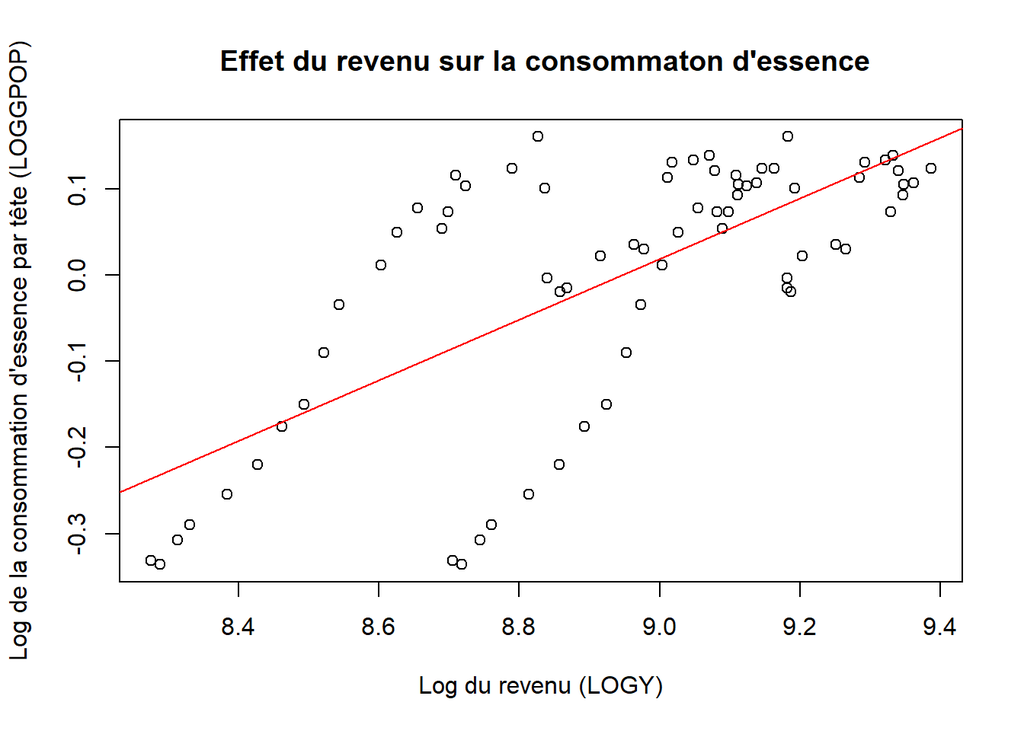

```r
plot(Essence$LOGY, Essence$LOGGPOP,
     main = " Effet du revenu sur la consommaton d'essence",
     xlab = "Log du revenu (LOGY)",
     ylab = "Log de la consommation d'essence par tête (LOGGPOP)")
abline(regtotal, col = "red")
```

# 7. Effectuez la même régression sur la période 1960-1975 (observations de 1 à 16). Stockez les résultats dans reg1. Faites de même sur la période 1976-1995 et stockez les résultats dans reg2. Affichez les droites de régression correspondantes sur le graphique précédent. Que constatez-vous? Quel test(s) serai(en)t alors approprié(s)?

```r
# Régression pour la période 1960-1975
reg1 <- lm(LOGGPOP ~ LOGY, data = Essence[1:16,])
summary(reg1)
```

```
##
## Call:
## lm(formula = LOGGPOP ~ LOGY, data = Essence[1:16, ])
##
## Residuals:
##       Min        1Q    Median        3Q       Max
## -0.041645 -0.021151  0.007849  0.020114  0.040628
##
## Coefficients:
##              Estimate Std. Error t value Pr(>|t|)
## (Intercept) -10.37390    0.45477  -22.81 1.80e-12 ***
## LOGY          1.15027    0.05098   22.57 2.08e-12 ***
## ---
## Signif. codes:  0 '***' 0.001 '**' 0.01 '*' 0.05 '.' 0.1 ' ' 1
##
## Residual standard error: 0.02776 on 14 degrees of freedom
## Multiple R-squared:  0.9732, Adjusted R-squared:  0.9713
## F-statistic: 509.2 on 1 and 14 DF,  p-value: 2.082e-12
```

```r
reg2 <- lm(LOGGPOP ~ LOGY, data = Essence[17:36,])
summary(reg2)
```

```
##
## Call:
## lm(formula = LOGGPOP ~ LOGY, data = Essence[17:36, ])
##
## Residuals:
##       Min        1Q    Median        3Q       Max
## -0.083033 -0.045668  0.003164  0.035582  0.097490
##
## Coefficients:
##             Estimate Std. Error t value Pr(>|t|)
## (Intercept)  -2.3482     1.3620  -1.724    0.102
## LOGY          0.2625     0.1470   1.786    0.091 .
## ---
## Signif. codes:  0 '***' 0.001 '**' 0.01 '*' 0.05 '.' 0.1 ' ' 1
##
## Residual standard error: 0.05225 on 18 degrees of freedom
## Multiple R-squared:  0.1505, Adjusted R-squared:  0.1033
## F-statistic: 3.188 on 1 and 18 DF,  p-value: 0.09102
```

# Créer le graphique

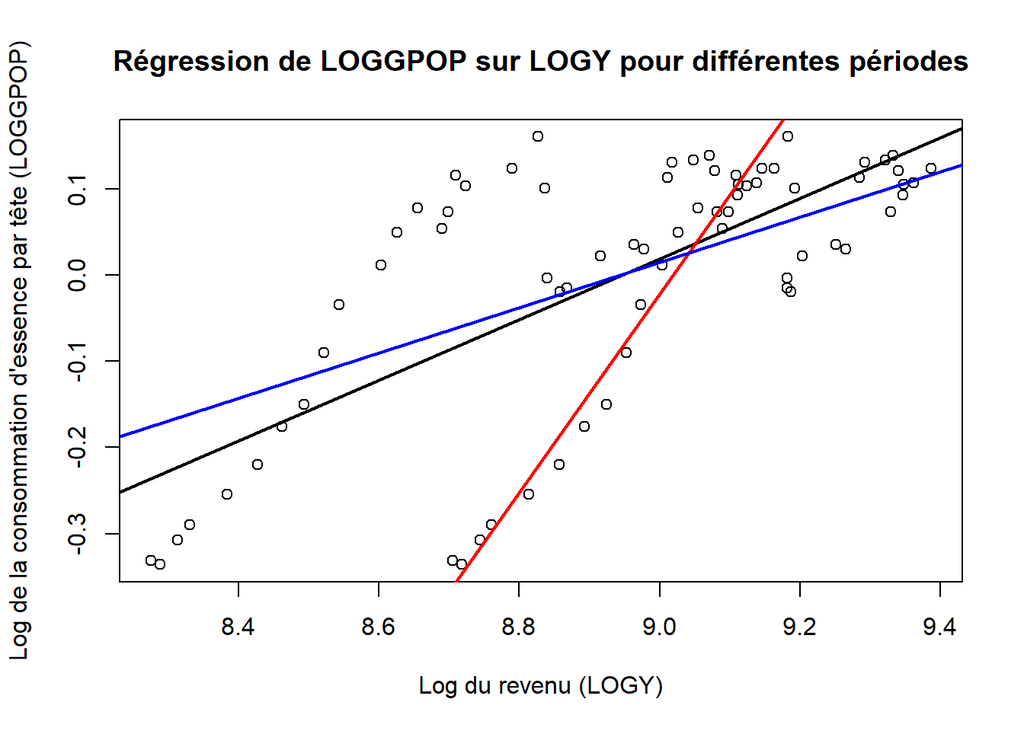

```r
plot(Essence$LOGY, Essence$LOGGPOP,
     main = "Régression de LOGGPOP sur LOGY pour différentes périodes",
     xlab = "Log du revenu (LOGY)",
     ylab = "Log de la consommation d'essence par tête (LOGGPOP)")
# Ajouter les droites de régression
abline(regtotal, col = "black", lwd = 2)
abline(reg1, col = "red", lwd = 2)
abline(reg2, col = "blue", lwd = 2)
```

```r
# Au lieu de prendre toutes les droites ....
```

# 8. Estimez les modèles suivants :

```r
# Modèle 1
modele1 <- lm(LOGGPOP ~ LOGY + LOGPG, data = Essence)
summary(modele1)
```

```
##
## Call:
## lm(formula = LOGGPOP ~ LOGY + LOGPG, data = Essence)
##
## Residuals:
##       Min        1Q    Median        3Q       Max
## -0.217349 -0.071672  0.002663  0.073335  0.214187
##
## Coefficients:
##             Estimate Std. Error t value Pr(>|t|)
## (Intercept) -2.06738    0.52926  -3.906 0.000216 ***
## LOGY         0.22443    0.06086   3.688 0.000447 ***
## LOGPG        0.08601    0.03022   2.846 0.005820 **
## ---
## Signif. codes:  0 '***' 0.001 '**' 0.01 '*' 0.05 '.' 0.1 ' ' 1
##
## Residual standard error: 0.1039 on 69 degrees of freedom
## Multiple R-squared:  0.5373, Adjusted R-squared:  0.5239
## F-statistic: 40.06 on 2 and 69 DF,  p-value: 2.843e-12
```

```r
# Modèle 2
modele2 <- lm(LOGGPOP ~ LOGY + LOGPG + LOGPNC, data = Essence)
summary(modele2)
```

```
##
## Call:
## lm(formula = LOGGPOP ~ LOGY + LOGPG + LOGPNC, data = Essence)
##
## Residuals:
##       Min        1Q    Median        3Q       Max
## -0.217143 -0.071350  0.003068  0.073172  0.214074
##
## Coefficients:
##              Estimate Std. Error t value Pr(>|t|)
## (Intercept) -2.071590   0.546403  -3.791 0.000321 ***
## LOGY         0.224935   0.062944   3.574 0.000653 ***
## LOGPG        0.088224   0.070041   1.260 0.212120
## LOGPNC      -0.004005   0.113885  -0.035 0.972049
## ---
## Signif. codes:  0 '***' 0.001 '**' 0.01 '*' 0.05 '.' 0.1 ' ' 1
##
## Residual standard error: 0.1047 on 68 degrees of freedom
## Multiple R-squared:  0.5373, Adjusted R-squared:  0.5169
## F-statistic: 26.32 on 3 and 68 DF,  p-value: 2.061e-11
```

```r
# Modèle 3
#modele3 <- lm(LOGGPOP ~ LOGY + LOGPG + LOGPNC + LOGPUC, data = Essence)
#summary(modele3)
```

```r
#install.packages("Epi", type="binary")
```

#9.Bonus : reprenons la base de donnée totale : influent sur la taille moyenne en France

```r
#Modeletaille <- lm(`TM France` ~ Gender + `Glorious?`, data = Essence)
#summary(Modeletaille)
```

```r
#Modeletaille2 <- lm(`TM France` ~ Gender + `Glorious?`+ Gender*`Glorious?`, data = Essence)
#summary(Modeletaille2)
```

# Autre façon

```r
#((deviance(modele2)-(deviance(modele21)+deviance(modele22)))/4)/((deviance(modele21)+deviance(modele22))/28) #4 paramètres : LOGY,LOGPG,LOGPNC,constante(epsilon)
#28 c'est : 16+20-2*4(paramètres)
```